```python
import pandas as pd
```

```python
file = "StudentsPerformance.csv"
data = pd.read_csv(file)
data.head()
```

|  | gender | race/ethnicity | parental level of education | lunch | test preparation course | math score | reading score | writing score |
| --- | --- | --- | --- | --- | --- | --- | --- | --- |
| 0 | female | group B | bachelor's degree | standard | none | 72 | 72 | 74 |
| 1 | female | group C | some college | standard | completed | 69 | 90 | 88 |
| 2 | female | group B | master's degree | standard | none | 90 | 95 | 93 |
| 3 | male | group A | associate's degree | free/reduced | none | 47 | 57 | 44 |
| 4 | male | group C | some college | standard | none | 76 | 78 | 75 |

# This dataset has 1000 rows and 8 columns.

```python
data.shape
```

```
(1000, 8)
```

# Checking for missing values.

```python
data.isnull().sum()
```

```
gender                         0
race/ethnicity                 0
parental level of education    0
lunch                          0
test preparation course        0
math score                     0
reading score                  0
writing score                  0
dtype: int64
```

# A. Short sentences addressing the objective(s)

The primary objective of this Python code is to perform a comprehensive Exploratory Data Analysis (EDA) on a dataset named 'StudentsPerformance.csv'. This is achieved by systematically inspecting, cleaning (if necessary), and visualizing the data to understand its structure, identify patterns, and find relationships between variables.

Dataset: (https://www.kaggle.com/datasets/spscientist/students-performance-in-exams/data) The dataset consists of 1000 participants from different backgrounds to understand the influence of the parents background, test preparation, and other factors on participants' performance.

# B. Pseudocode and/or flowchart

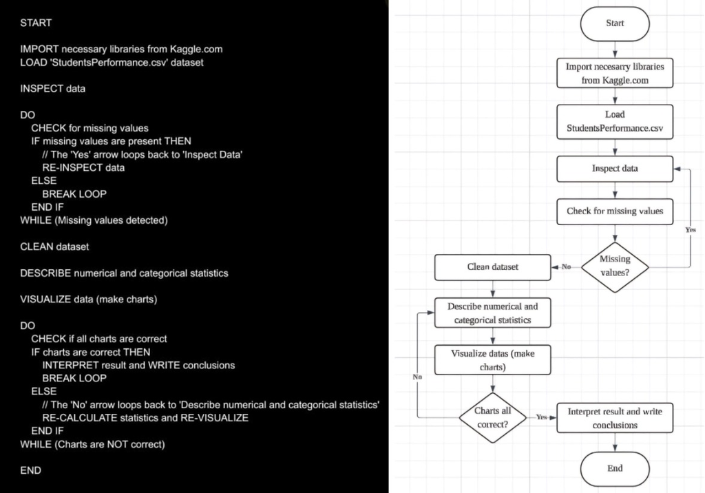

```python
from IPython.display import Image, display
display(Image(filename='Pseudocode and Flowchart.jpeg'))
```